# Developing an AI application

In this project, I trained an image classifier to recognize different species of flowers. I'll be using [this dataset](http://www.robots.ox.ac.uk/~vgg/data/flowers/102/index.html) of 102 flower categories, you can see a few examples below.

[figure not shown]

```python
# Imports here
import matplotlib.pyplot as plt
import matplotlib.image as mpimg
import numpy as np
import torch
from torch import nn, optim
import torch.nn.functional as F
from torchvision import datasets, transforms, models
import torchvision.models as models
from torch.autograd import Variable
from PIL import Image
import json
from matplotlib.ticker import FormatStrFormatter
from collections import OrderedDict
import os, random
```

## Load the data

Here I used `torchvision` to load the data ([documentation](http://pytorch.org/docs/0.3.0/torchvision/index.html)). The data should be included alongside this notebook, otherwise [download it here](https://s3.amazonaws.com/content.udacity-data.com/nd089/flower_data.tar.gz). The dataset is split into three parts, training, validation, and testing. For the training, I applied transformations such as random scaling, cropping, and flipping. This will help the network generalize leading to better performance. I also made sure the input data is resized to 224x224 pixels as required by the pre-trained networks.

The validation and testing sets are used to measure the model's performance on data it hasn't seen yet. For this I didn't apply any scaling or rotation transformations, but I resized then croped the images to the appropriate size.

The pre-trained networks I used were trained on the ImageNet dataset where each color channel was normalized separately. For all three sets I normalized the means and standard deviations of the images to what the network expects. For the means, it's `[0.485, 0.456, 0.406]` and for the standard deviations `[0.229, 0.224, 0.225]`, calculated from the ImageNet images. These values will shift each color channel to be centered at 0 and range from -1 to 1.

```python
data_dir = 'flowers'
train_dir = data_dir + '/train'
valid_dir = data_dir + '/valid'
test_dir = data_dir + '/test'
```

```python
# Define transforms for the training, validation, and testing sets
train_transforms = transforms.Compose([transforms.RandomRotation(30),
                                       transforms.RandomResizedCrop(224),
                                       transforms.RandomHorizontalFlip(),
                                       transforms.ToTensor(),
                                       transforms.Normalize([0.485, 0.456, 0.406],
                                                            [0.229, 0.224, 0.225])])

test_transforms = transforms.Compose([transforms.Resize(256),
                                      transforms.CenterCrop(224),
                                      transforms.ToTensor(),
                                      transforms.Normalize([0.485, 0.456, 0.406],
                                                           [0.229, 0.224, 0.225])])

validation_transforms = transforms.Compose([transforms.Resize(256),
                                            transforms.CenterCrop(224),
                                            transforms.ToTensor(),
                                            transforms.Normalize([0.485, 0.456, 0.406],
                                                                 [0.229, 0.224, 0.225])])

# Load the datasets with ImageFolder
train_data = datasets.ImageFolder(train_dir, transform=train_transforms)
validation_data = datasets.ImageFolder(valid_dir, transform=validation_transforms)
test_data = datasets.ImageFolder(test_dir ,transform = test_transforms)

# Using the image datasets and the trainforms, define the dataloaders
trainloader = torch.utils.data.DataLoader(train_data, batch_size=64, shuffle=True)
validloader = torch.utils.data.DataLoader(validation_data, batch_size =32,shuffle = True)
testloader = torch.utils.data.DataLoader(test_data, batch_size = 20, shuffle = True)
```

### Label mapping

I also needed to load in a mapping from category label to category name. It is found in the file `cat_to_name.json`. It's a JSON object which can be read in with the [`json` module](https://docs.python.org/2/library/json.html). This will give a dictionary mapping the integer encoded categories to the actual names of the flowers.

```python
with open('cat_to_name.json', 'r') as f:
    cat_to_name = json.load(f)
```

# Building and training the classifier

Now that the data is ready, it's time to build and train the classifier. I used one of the pretrained models from `torchvision.models` to get the image features.

```python
model = models.vgg19(pretrained=True)
model
for param in model.parameters():
    param.requires_grad = False
```

```
Downloading: "https://download.pytorch.org/models/vgg19-dcbb9e9d.pth" to /root/.torch/models/vgg19-dcbb9e9d.pth
```

```python
class Network(nn.Module):
    def __init__(self, input_size, output_size, hidden_layers, drop_p = 0.5):
        super().__init__()
        self.hidden_layers = nn.ModuleList([nn.Linear(input_size, hidden_layers[0])])

        layer_sizes = zip(hidden_layers[:-1], hidden_layers[1:])
        self.hidden_layers.extend([nn.Linear(h1, h2) for h1, h2 in layer_sizes])
        self.output = nn.Linear(hidden_layers[-1], output_size)
        self.dropout = nn.Dropout(p = drop_p)

    def forward(self, x):
        for each in self.hidden_layers:
            x = F.relu(each(x))
            x = self.dropout(x)
        x = self.output(x)
        return F.log_softmax(x, dim = 1)
nmodel = Network(25088, 102, [2900], drop_p = 0.5)
model.classifier = nmodel
nmodel

criterion = nn.NLLLoss()
optimizer = optim.SGD(model.classifier.parameters(), lr = 0.03)
```

```python
def valid_loss_acc(model, loader, criterion):
    cuda = torch.cuda.is_available()
    if cuda:
        model.cuda()
    else:
        model.cpu()
    model.eval()
    accuracy = 0
    loss = 0
    with torch.no_grad():
        for images, labels in loader:
            images, labels = images.to('cuda'), labels.to('cuda')
            output = model(images)
            ps = torch.exp(output)
            equals = (labels.data == ps.max(1)[1])
            accuracy += equals.type_as(torch.FloatTensor()).mean()
            loss += criterion(output, labels)
    return accuracy / len(loader), loss / len(loader)
```

```python
def train(model, trainloader, validationloader, criterion, optimizer, epochs, print_every = 40):
    cuda = torch.cuda.is_available()
    if cuda:
        model.cuda()
    else:
        model.cpu()
    steps = 0
    model.to('cuda')
    model.train()
    for e in range(epochs):
        running_loss=0
        for ii, (images,labels) in enumerate(trainloader):
            images, labels = images.to('cuda'), labels.to('cuda')
            steps += 1
            optimizer.zero_grad()
            output = model.forward(images)
            loss = criterion(output,labels)
            loss.backward()
            optimizer.step()
            running_loss += loss.item()

            if steps % print_every == 0:
                accuracy, validation_loss = valid_loss_acc(model, validloader, criterion)
                print("Epoch: {}/{} ".format(e+1, epochs),
                      "Training Loss: {:.4f} ".format(running_loss / print_every),
                      "Validation Loss: {:.4f} ".format(validation_loss),
                      "Validation Accuracy: {:.4f}".format(accuracy))
                running_loss = 0
            model.train()
train(model, trainloader, validloader, criterion, optimizer, 6, 40)
```

```
Epoch: 1/6  Training Loss: 0.6951  Validation Loss: 0.3927  Validation Accuracy: 0.8873
Epoch: 1/6  Training Loss: 0.6884  Validation Loss: 0.4467  Validation Accuracy: 0.8616
Epoch: 2/6  Training Loss: 0.2836  Validation Loss: 0.3708  Validation Accuracy: 0.8861
Epoch: 2/6  Training Loss: 0.6666  Validation Loss: 0.4049  Validation Accuracy: 0.8813
Epoch: 2/6  Training Loss: 0.6686  Validation Loss: 0.3962  Validation Accuracy: 0.8815
Epoch: 3/6  Training Loss: 0.5128  Validation Loss: 0.3640  Validation Accuracy: 0.8909
Epoch: 3/6  Training Loss: 0.6524  Validation Loss: 0.3856  Validation Accuracy: 0.8851
Epoch: 4/6  Training Loss: 0.1767  Validation Loss: 0.3629  Validation Accuracy: 0.8860
Epoch: 4/6  Training Loss: 0.6073  Validation Loss: 0.3759  Validation Accuracy: 0.8906
Epoch: 4/6  Training Loss: 0.6079  Validation Loss: 0.3480  Validation Accuracy: 0.9002
Epoch: 5/6  Training Loss: 0.3890  Validation Loss: 0.3905  Validation Accuracy: 0.8978
Epoch: 5/6  Training Loss: 0.5927  Validation Loss: 0.3841  Validation Accuracy: 0.8779
Epoch: 6/6  Training Loss: 0.0705  Validation Loss: 0.3549  Validation Accuracy: 0.8993
Epoch: 6/6  Training Loss: 0.5422  Validation Loss: 0.3436  Validation Accuracy: 0.9041
Epoch: 6/6  Training Loss: 0.5538  Validation Loss: 0.3235  Validation Accuracy: 0.9101
```

## Testing the network

```python
# Do validation on the test set
test_accuracy, test_loss = valid_loss_acc(model, testloader, criterion)
print("Test Accuracy: {:.4f} ".format(test_accuracy), "Test Loss: {:.4f}".format(test_loss))
```

```
Test Accuracy: 0.8472  Test Loss: 0.5075
```

## Save the checkpoint

Now that the network is trained, I saved the model so thta I can load it later for making predictions.

```python
# Save the checkpoint
def save_checkpoint(model, optimizer):
    model.class_to_idx = train_data.class_to_idx
    checkpoint = {'arch': 'vgg19',
                  'in_size': 25088,
                  'out_size': 102,
                  'hidden_layers': [each.out_features for each in model.classifier.hidden_layers],
                  'drop_p': model.classifier.dropout.p,
                  'optimizer': optimizer.state_dict(),
                  'state_dict': model.classifier.state_dict(),
                  'class_to_idx': model.class_to_idx}
torch.save(checkpoint, 'checkpoint.pth')
```

## Loading the checkpoint

I wrote a function that can load a checkpoint and rebuild the model. That way I can come back to this project and keep working on it without having to retrain the network.

```python
# Write a function that loads a checkpoint and rebuilds the model
def load_checkpoint(filename):
    cuda = torch.cuda.is_available()
    if cuda:
        model.cuda()
    else:
        model.cpu()
    model = models.vgg19(pretrained=True)
    checkpoint = torch.load(filename)
    loadedmodel = Network(checkpoint['in_size'],
                          checkpoint['out_size'],
                          checkpoint['hidden_layers'],
                          checkpoint['drop_p'])
    loadedmodel.load_state_dict(checkpoint['state_dict'])
    model.classifier = loadedmodel
    model = model.float().to('cuda')
    return model
load_checkpoint('checkpoint.pth')
```

[output not shown]

# Inference for classification

Now I wrote a function to use a trained network for inference. That is, I'll pass an image into the network and predict the class of the flower in the image. The function called `predict` takes an image and a model, then returns the top $K$ most likely classes along with the probabilities. It should look like

```
probs, classes = predict(image_path, model)
print(probs)
print(classes)
> [ 0.01558163  0.01541934  0.01452626  0.01443549  0.01407339]
> ['70', '3', '45', '62', '55']
```

## Image Preprocessing

I used `PIL` to load the image ([documentation](https://pillow.readthedocs.io/en/latest/reference/Image.html)).

First, I resized the images where the shortest side is 256 pixels, keeping the aspect ratio. This can is done with the [`thumbnail`](http://pillow.readthedocs.io/en/3.1.x/reference/Image.html#PIL.Image.Image.thumbnail) or [`resize`](http://pillow.readthedocs.io/en/3.1.x/reference/Image.html#PIL.Image.Image.thumbnail) methods. Then I cropped out the center 224x224 portion of the image.

Color channels of images are typically encoded as integers 0-255, but the model expected floats 0-1. I needed to convert the values.

As before, the network expects the images to be normalized in a specific way. I subtracted the means from each color channel, and then divided by the standard deviation.

And finally, PyTorch expects the color channel to be the first dimension but it's the third dimension in the PIL image and Numpy array. I reordered dimensions using [`ndarray.transpose`](https://docs.scipy.org/doc/numpy-1.13.0/reference/generated/numpy.ndarray.transpose.html). The color channel needs to be first and retain the order of the other two dimensions.

```python
def process_image(image):
    ''' Scales, crops, and normalizes a PIL image for a PyTorch model,
        returns an Numpy array
    '''

    # Process a PIL image for use in a PyTorch model
    img = Image.open(image)
    img_transforms = transforms.Compose([transforms.Resize(256),
                                         transforms.CenterCrop(224),
                                         transforms.ToTensor()])
    img = img_transforms(img)
    img = np.array(img)
    mean = np.array([0.485, 0.456, 0.406])
    std = np.array([0.229, 0.224, 0.225])
    img = (np.transpose(img, (1, 2, 0)) - mean) / std
    img = np.transpose(img, (2, 0, 1))
    return img
```

To check the work, the function below converts a PyTorch tensor and displays it in the notebook. If the `process_image` function works, running the output through this function should return the original image (except for the cropped out portions).

```python
def imshow(image, ax=None, title=None):
    if ax is None:
        fig, ax = plt.subplots()

    # PyTorch tensors assume the color channel is first
    # but matplotlib assumes is the third dimension
    image = image.transpose((1, 2, 0))

    # Undo preprocessing
    mean = np.array([0.485, 0.456, 0.406])
    std = np.array([0.229, 0.224, 0.225])
    image = std * image + mean

    # Image needs to be clipped between 0 and 1
    image = np.clip(image, 0, 1)

    ax.imshow(image)

    return ax
```

## Class Prediction

Once I get the images in the correct format, it's time to write a function for making predictions with the model.

To get the top $K$ largest values in a tensor I used [`x.topk(k)`](http://pytorch.org/docs/master/torch.html#torch.topk). This method returns both the highest `k` probabilities and the indices of those probabilities corresponding to the classes. I needed to convert from these indices to the actual class labels using `class_to_idx`.

```
probs, classes = predict(image_path, model)
print(probs)
print(classes)
> [ 0.01558163  0.01541934  0.01452626  0.01443549  0.01407339]
> ['70', '3', '45', '62', '55']
```

```python
def predict(image_path, model, topk=5):
    ''' Predict the class (or classes) of an image using a trained deep learning model.
    '''
    # Implement the code to predict the class from an image file
    image = Image.open(image_path)
    image = helper.process_image(image)
    image = torch.from_numpy(image).type(torch.FloatTensor)
    inputs = Variable(image, requires_grad=False)
    inputs = inputs.unsqueeze(0)
    if cuda:
        inputs = inputs.cuda()
        model.cuda()
    ps = torch.exp(model.forward(inputs))
    if cuda:
        ps.cuda()
    top_probs, top_labels = ps.topk(top_k)
    top_probs, top_labels = top_probs.data.cpu().numpy().squeeze(), top_labels.data.cpu().numpy().squeeze()
    idx_to_class = {v: key for key, v in model.class_to_idx.items()}
    if top_k == 1:
        top_classes = [idx_to_class[int(top_labels)]]
        top_probs = [float(top_probs)]
    else:
        top_classes = [idx_to_class[each] for each in top_labels]

    return top_probs, top_classes
```

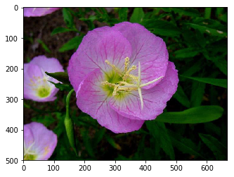

```python
img = random.choice(os.listdir('./flowers/test/1/'))
img_path = './flowers/test/1/' + img

with Image.open(img_path) as image:
    plt.imshow(image)
```

## Sanity Checking

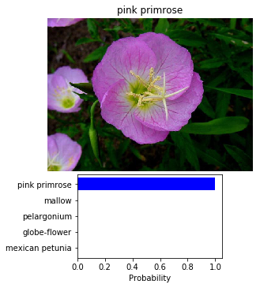

```python
# Display an image along with the top 5 classes
prob, classes = predict(img_path, model)
max_index = np.argmax(prob)
max_probability = prob[max_index]
label = classes[max_index]

fig = plt.figure(figsize=(6,6))
ax1 = plt.subplot2grid((15,9), (0,0), colspan=9, rowspan=9)
ax2 = plt.subplot2grid((15,9), (9,2), colspan=5, rowspan=5)

image = Image.open(img_path)
ax1.axis('off')
ax1.set_title(cat_to_name[label])
ax1.imshow(image)

labels = []
for cl in classes:
    labels.append(cat_to_name[cl])

y_pos = np.arange(5)
ax2.set_yticks(y_pos)
ax2.set_yticklabels(labels)
ax2.set_xlabel('Probability')
ax2.invert_yaxis()
ax2.barh(y_pos, prob, xerr=0, align='center', color='blue')

plt.show()
```

[figure not shown]

```python
img = (test_dir + '/10/' + 'image_07104.jpg')
probs, classes = predict(img, model)
check_sanity(img, probs, classes, cat_to_name)
```